# Reproducible Research - Week 2 Assignment

Raymond Schneider

May 31, 2016

## Libraries

Load required libraries.

```r
library('ggplot2')
```

## Loading and preprocessing the data

1. Load the Data

From the Repo, download and extract the Activity Monitoring Data (repdata-data-activity.zip). Extract in the working directory and set you directory, then import data.

```r
data <- read.csv("activity.csv")
```

2. Process/transform the data (if necessary) into a format suitable for your analysis

Make an aggrated data set showing steps by day.

```r
aggSteps <- aggregate(steps ~ date,data,sum)
head(aggSteps)
```

```
##         date steps
## 1 2012-10-02   126
## 2 2012-10-03 11352
## 3 2012-10-04 12116
## 4 2012-10-05 13294
## 5 2012-10-06 15420
## 6 2012-10-07 11015
```

## What is the mean total number of steps taken per day?

1. Make a histogram of the total number of steps taken each day

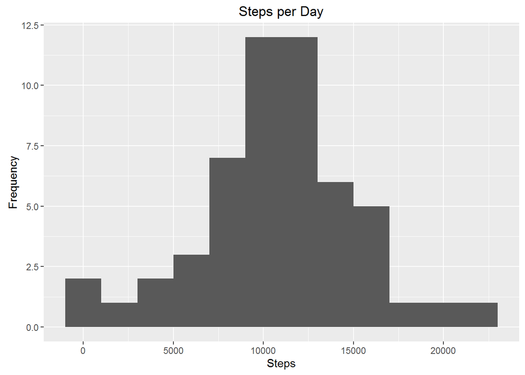

```r
p <- qplot(steps, data=aggSteps, geom="histogram", binwidth=2000)
p <- p + labs(title = "Steps per Day", x = "Steps", y = "Frequency")
p
```

2. Calculate and report the mean and median total number of steps taken per day.

I like summary statistics, so here they are, mean and median included:

```r
summary(aggSteps$steps)
```

```
##    Min. 1st Qu.  Median    Mean 3rd Qu.    Max.
##      41    8841   10760   10770   13290   21190
```

## What is the average daily activity pattern?

1. Make a time series plot (i.e. type = “l”) of the 5-minute interval (x-axis) and the average number of steps taken, averaged across all days (y-axis)

Use aggregate() and ggplot2 to make the plot.

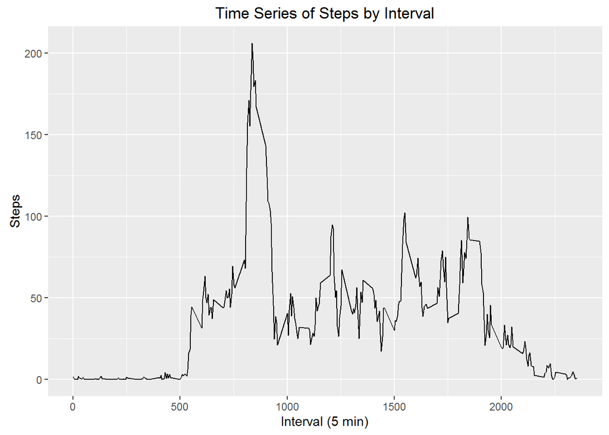

```r
timeSteps <- aggregate(steps ~ interval,data,mean)
ggplot(timeSteps, aes(interval,steps)) + geom_line() + xlab("Interval (5 min)") + ylab("Steps") + ggtitle("Time Series of Steps by Interval")
```

2. Which 5-minute interval, on average across all the days in the dataset, contains the maximum number of steps?

Order the data by ‘steps’ in descending order and take the first result.

```r
attach(timeSteps)
head(timeSteps[order(-steps),],1)
```

```
##     interval    steps
## 104      835 206.1698
```

```r
detach(timeSteps)
```

## Imputing missing values

1. Calculate and report the total number of missing values in the dataset (i.e. the total number of rows with NAs)

Use the sum of NOT complete.cases() to do this quickly:

```r
sum(!complete.cases(data))
```

```
## [1] 2304
```

2. Devise a strategy for filling in all of the missing values in the dataset. The strategy does not need to be sophisticated. For example, you could use the mean/median for that day, or the mean for that 5-minute interval, etc.

Since this “does not need to be sophisticated” I’ll just replace NA values with the mean of all values for that interval. It might be more interesting to try and take the average of the preceding and proceding interval, but that is starting to get sophisticated, so I’ll do it the easy way.

First we make a function to read ‘steps’ and check for missing values. If there is not a missing value in ‘steps’ the function returns the current value. If there is a missing value, the function reads in the mean from the ‘timeSteps’ data frame and returns the mean corresponding to the interval with the missing value.

```r
checkValue <- function(steps,interval) {
        imputeValue <- NA
        if (!is.na(steps))
                imputeValue <- c(steps)
        else
                imputeValue <- (timeSteps[timeSteps$interval==interval, "steps"])
        return(imputeValue)
}
```

3. Create a new dataset that is equal to the original dataset but with the missing data filled in.

Now we make a new data set to store the imputed data, and use mapply() to apply the checkValue function over the original data.

```r
imputed.Data <- data
imputed.Data$steps <- mapply(checkValue, imputed.Data$steps, imputed.Data$interval)
```

And we check for NA values after running the function, to make sure it actually replaced all the NAs.

```r
sum(!complete.cases(imputed.Data))
```

```
## [1] 0
```

4. Make a histogram of the total number of steps taken each day and Calculate and report the mean and median total number of steps taken per day. Do these values differ from the estimates from the first part of the assignment? What is the impact of imputing missing data on the estimates of the total daily number of steps?

We can repeat our work from earlier witha few modifications:

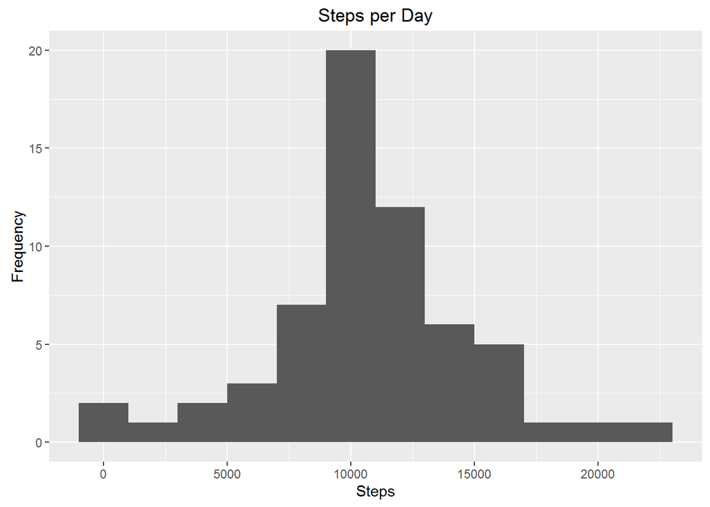

```r
aggStepsNew <- aggregate(steps ~ date,imputed.Data,sum)

p <- qplot(steps, data=aggStepsNew, geom="histogram", binwidth=2000)
p <- p + labs(title = "Steps per Day", x = "Steps", y = "Frequency")
p
```

```r
summary(aggStepsNew$steps)
```

```
##    Min. 1st Qu.  Median    Mean 3rd Qu.    Max.
##      41    9819   10770   10770   12810   21190
```

```r
original <- summary(aggSteps$steps)
imputed <- summary(aggStepsNew$steps)

MedianDiff <- imputed[3]-original[3]
MeanDiff <- imputed[4]-original[4]

MedianDiff
```

```
## Median
##     10
```

```r
MeanDiff
```

```
## Mean
##    0
```

The median is slightly higher. The mean remains the same. Since I used the aggregate() function, which ignores missing values, it makes sense that adding more mean values would not shift the mean. However, adding more values can shift the median.

## Are there differences in activity patterns between weekdays and weekends?

1. Create a new factor variable in the dataset with two levels - “weekday” and “weekend” indicating whether a given date is a weekday or weekend day.

First we use the weekdays() function with as.POSIXct() to transform the date column into the actual days of the week. Then we make a function to return the weekend/weekday level based on the string in the new ‘day’ variable.

```r
imputed.Data$day <- weekdays(as.POSIXct(imputed.Data$date))

daytype <- function(day) {
        if (day %in% c('Monday','Tuesday','Wednesday','Thrusday','Friday'))
                wkday <- "Weekday"
        else
                wkday <- "Weekend"
        return(wkday)
}

imputed.Data$week <- mapply(daytype, imputed.Data$day)
```

2. Make a panel plot containing a time series plot (i.e. type = “l”) of the 5-minute interval (x-axis) and the average number of steps taken, averaged across all weekday days or weekend days (y-axis). See the README file in the GitHub repository to see an example of what this plot should look like using simulated data.

Use aggregate() on our data form the previous step to get the means by interval and week/weekend, then use ggplot to make the panels.

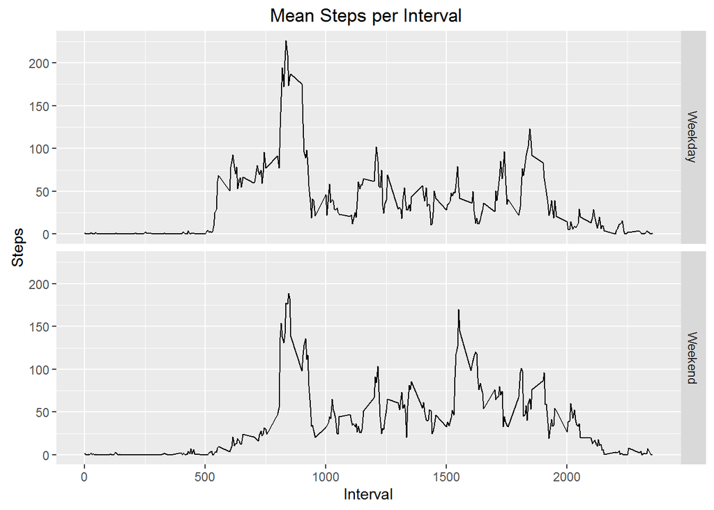

```r
timeStepsLast <- aggregate(steps ~ interval+week,imputed.Data,mean)

ggplot(timeStepsLast, aes(interval,steps))+geom_line()+facet_grid(week ~ .) + labs(title = "Mean Steps per Interval ", x = "Interval", y = "Steps")
```